# Project: Soccer Data Analysis

- Introduction
- Data Wrangling
- Exploratory Data Analysis
- Conclusions

## Introduction

### Dataset Description

- This soccer database comes from Kaggle and is well suited for data analysis and machine learning. It contains data for soccer matches, players, and teams from several European countries from 2008 to 2016. For this part. I will use two datasets, the Player and Player_Attributes. for more information click [here](https://www.google.com/url?q=https://www.kaggle.com/hugomathien/soccer&sa=D&ust=1532469042123000)

### Question(s) for Analysis

#### The following question are going to be answered throughout the analysis

1. What is the distribution of the overall rating on the given dataset?
2. Which varible is best characteristics of the higly rated player?
3. Which type of prefered foot (left or right) is associated with high player rating?
4. Do player with higher dribble skill receive better ratings?
5. What is the name of the player that has better rating?
6. Which players had the most penalties?

```python
# importing all neccessary liberaries
import matplotlib.pyplot as plt
import sqlite3 as sql
#import seabron
import pandas as pd
import numpy as np
import seaborn as sb
%matplotlib inline
```

## Data Wrangling

### General Properties

```python
# loding datasets
# since the datasets are in sql format, it needs to connect for successfull reading by the datafame object
connect = sql.connect('database.sqlite') # connection to the database
df_pa = pd.read_sql("select * from Player_Attributes", con = connect) # datafram for the player attribute
df_p= pd.read_sql("select * from Player", con = connect) # dataframe for the player
```

```python
#checking the dataset, using head()
df_pa.head(1)
```

|  | id | player_fifa_api_id | player_api_id | date | overall_rating | potential | preferred_foot | attacking_work_rate | defensive_work_rate | crossing | ... | vision | penalties | marking | standing_tackle | sliding_tackle | gk_diving | gk_handling | gk_kicking | gk_positioning | gk_reflexes |
| --- | --- | --- | --- | --- | --- | --- | --- | --- | --- | --- | --- | --- | --- | --- | --- | --- | --- | --- | --- | --- | --- |
| 0 | 1 | 218353 | 505942 | 2016-02-18 00:00:00 | 67.0 | 71.0 | right | medium | medium | 49.0 | ... | 54.0 | 48.0 | 65.0 | 69.0 | 69.0 | 6.0 | 11.0 | 10.0 | 8.0 | 8.0 |

1 rows × 42 columns

```python
#checking for the Player
df_p.head(1)
```

|  | id | player_api_id | player_name | player_fifa_api_id | birthday | height | weight |
| --- | --- | --- | --- | --- | --- | --- | --- |
| 0 | 1 | 505942 | Aaron Appindangoye | 218353 | 1992-02-29 00:00:00 | 182.88 | 187 |

```python
#checking the data against general information
df_pa.info()
```

```
<class 'pandas.core.frame.DataFrame'>
RangeIndex: 183978 entries, 0 to 183977
Data columns (total 42 columns):
 #   Column               Non-Null Count   Dtype
---  ------               --------------   -----
 0   id                   183978 non-null  int64
 1   player_fifa_api_id   183978 non-null  int64
 2   player_api_id        183978 non-null  int64
 3   date                 183978 non-null  object
 4   overall_rating       183142 non-null  float64
 5   potential            183142 non-null  float64
 6   preferred_foot       183142 non-null  object
 7   attacking_work_rate  180748 non-null  object
 8   defensive_work_rate  183142 non-null  object
 9   crossing             183142 non-null  float64
```

[output cut: 34 more lines]

```python
df_p.info()
```

```
<class 'pandas.core.frame.DataFrame'>
RangeIndex: 11060 entries, 0 to 11059
Data columns (total 7 columns):
 #   Column              Non-Null Count  Dtype
---  ------              --------------  -----
 0   id                  11060 non-null  int64
 1   player_api_id       11060 non-null  int64
 2   player_name         11060 non-null  object
 3   player_fifa_api_id  11060 non-null  int64
 4   birthday            11060 non-null  object
 5   height              11060 non-null  float64
 6   weight              11060 non-null  int64
dtypes: float64(1), int64(4), object(2)
memory usage: 605.0+ KB
```

```python
#geral descriprtion about the data interms of statistics
df_pa.describe()
```

|  | id | player_fifa_api_id | player_api_id | overall_rating | potential | crossing | finishing | heading_accuracy | short_passing | volleys | ... | vision | penalties | marking | standing_tackle | sliding_tackle | gk_diving | gk_handling | gk_kicking | gk_positioning | gk_reflexes |
| --- | --- | --- | --- | --- | --- | --- | --- | --- | --- | --- | --- | --- | --- | --- | --- | --- | --- | --- | --- | --- | --- |
| count | 183978.00000 | 183978.000000 | 183978.000000 | 183142.000000 | 183142.000000 | 183142.000000 | 183142.000000 | 183142.000000 | 183142.000000 | 181265.000000 | ... | 181265.000000 | 183142.000000 | 183142.000000 | 183142.000000 | 181265.000000 | 183142.000000 | 183142.000000 | 183142.000000 | 183142.000000 | 183142.000000 |
| mean | 91989.50000 | 165671.524291 | 135900.617324 | 68.600015 | 73.460353 | 55.086883 | 49.921078 | 57.266023 | 62.429672 | 49.468436 | ... | 57.873550 | 55.003986 | 46.772242 | 50.351257 | 48.001462 | 14.704393 | 16.063612 | 20.998362 | 16.132154 | 16.441439 |
| std | 53110.01825 | 53851.094769 | 136927.840510 | 7.041139 | 6.592271 | 17.242135 | 19.038705 | 16.488905 | 14.194068 | 18.256618 | ... | 15.144086 | 15.546519 | 21.227667 | 21.483706 | 21.598778 | 16.865467 | 15.867382 | 21.452980 | 16.099175 | 17.198155 |
| min | 1.00000 | 2.000000 | 2625.000000 | 33.000000 | 39.000000 | 1.000000 | 1.000000 | 1.000000 | 3.000000 | 1.000000 | ... | 1.000000 | 2.000000 | 1.000000 | 1.000000 | 2.000000 | 1.000000 | 1.000000 | 1.000000 | 1.000000 | 1.000000 |
| 25% | 45995.25000 | 155798.000000 | 34763.000000 | 64.000000 | 69.000000 | 45.000000 | 34.000000 | 49.000000 | 57.000000 | 35.000000 | ... | 49.000000 | 45.000000 | 25.000000 | 29.000000 | 25.000000 | 7.000000 | 8.000000 | 8.000000 | 8.000000 | 8.000000 |
| 50% | 91989.50000 | 183488.000000 | 77741.000000 | 69.000000 | 74.000000 | 59.000000 | 53.000000 | 60.000000 | 65.000000 | 52.000000 | ... | 60.000000 | 57.000000 | 50.000000 | 56.000000 | 53.000000 | 10.000000 | 11.000000 | 12.000000 | 11.000000 | 11.000000 |
| 75% | 137983.75000 | 199848.000000 | 191080.000000 | 73.000000 | 78.000000 | 68.000000 | 65.000000 | 68.000000 | 72.000000 | 64.000000 | ... | 69.000000 | 67.000000 | 66.000000 | 69.000000 | 67.000000 | 13.000000 | 15.000000 | 15.000000 | 15.000000 | 15.000000 |
| max | 183978.00000 | 234141.000000 | 750584.000000 | 94.000000 | 97.000000 | 95.000000 | 97.000000 | 98.000000 | 97.000000 | 93.000000 | ... | 97.000000 | 96.000000 | 96.000000 | 95.000000 | 95.000000 | 94.000000 | 93.000000 | 97.000000 | 96.000000 | 96.000000 |

8 rows × 38 columns

```python
df_p.describe()
```

|  | id | player_api_id | player_fifa_api_id | height | weight |
| --- | --- | --- | --- | --- | --- |
| count | 11060.000000 | 11060.000000 | 11060.000000 | 11060.000000 | 11060.000000 |
| mean | 5537.511392 | 156582.427215 | 165664.910488 | 181.867445 | 168.380289 |
| std | 3197.692647 | 160713.700624 | 58649.928360 | 6.369201 | 14.990217 |
| min | 1.000000 | 2625.000000 | 2.000000 | 157.480000 | 117.000000 |
| 25% | 2767.750000 | 35555.500000 | 151889.500000 | 177.800000 | 159.000000 |
| 50% | 5536.500000 | 96619.500000 | 184671.000000 | 182.880000 | 168.000000 |
| 75% | 8306.250000 | 212470.500000 | 203883.250000 | 185.420000 | 179.000000 |
| max | 11075.000000 | 750584.000000 | 234141.000000 | 208.280000 | 243.000000 |

```python
# checking their shape
df_pa.shape, df_p.shape
```

```
((183978, 42), (11060, 7))
```

```python
#checking against duplicated observation
df_pa.duplicated().any().sum()
```

```
0
```

```python
#checking angainst duplicated observation in player dataset
df_p.duplicated().sum()
```

```
0
```

### Data Cleaning

In the above particularly, player attribute dataframe, there are missing values/null values. On the other hand there is no duplication in both dataframe. **regarding** to handling the missing value, droping the observations with missing value is applied.

```python
#the number of missing value
df_pa.isnull().any().sum()
```

```
38
```

```python
#checking agains the number of missing values
df_p.isnull().any().sum()
```

```
0
```

#### Handling Missing value

there is no duplicated observation. lets drop the observation with missing value

```python
# Dropping null value
df_pa.dropna(axis = 0, inplace = True)
```

```python
# confirming no observation with null value
df_pa.isnull().any().sum()
```

```
0
```

```python
df_pa.shape;
```

```python
# After dropping the observation with null value
df_pa.shape
```

```
(180354, 42)
```

## Exploratory Data Analysis

- in this phase, data visualization and answering questions related the given dataset is presented.

### The depedant variable for this analysis is **Overall_rating**

### Research Question 1: What is the distribution of the overall rating on the given dataset?

- To answer this question, it is possible to use histogram, bar chart and pie chart. so that it can be easly draw the finding.

```python
# let's first find the frequency of each unique value of the overal_rating variable
df_pa['overall_rating'].value_counts() # returns unique value in decending order
```

```
68.0    10372
69.0    10178
67.0    10064
66.0     9963
70.0     9899
        ...
38.0        8
35.0        5
36.0        3
37.0        3
33.0        2
Name: overall_rating, Length: 61, dtype: int64
```

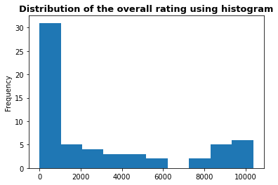

```python
# using histogram to visualize
df_pa['overall_rating'].value_counts().plot(kind = 'hist');
plt.title("Distribution of the overall rating using histogram", fontsize = 13, fontweight = 'bold');
```

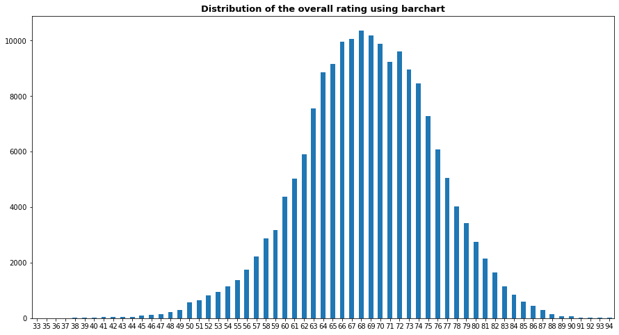

```python
# using barchart visualization
df_pa['overall_rating'] = df_pa['overall_rating'].astype(int)
df_pa['overall_rating'].value_counts().sort_index().plot(kind = 'bar', figsize = (15,8), rot = 0); # sorting and ploting
plt.title("Distribution of the overall rating using barchart", fontsize = 13, fontweight = 'bold');
```

### Research Question 2 : Which varible is best characteristics of the higly rated player?

- To answer the above question, six independent variables are selected. The variables are to be checked their correlation with the dependent variable. As a result, the variable with higher positive correlation would be identified.
- The dependant variable is: **overall_rating**
- the independent variables are: **potential, dribbling, vision, free_kick_accuracy, finishing, penalties**

#### Scatterplots of Overall_rating against the selected independent variable

- To visualze and see their correltion, scatterplot is one way to do that.

```python
# first lets create sub dataframe of the selected independent variable
df_pa1 = df_pa[['potential', 'dribbling', 'vision','free_kick_accuracy', 'finishing', 'penalties']].copy()# creating new dataframe with selected variables
```

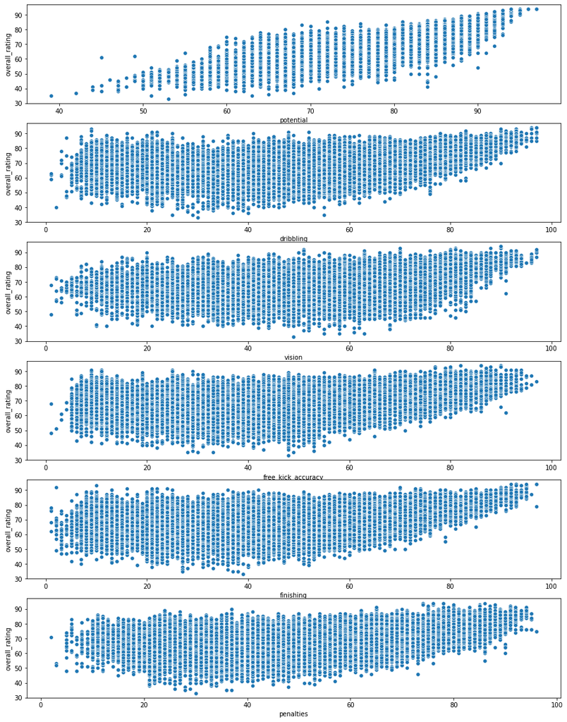

```python
# Next checking correlation using scatterplots
def scatter_plot(df):
    count=1
    plt.subplots(figsize=(15, 20))
    for c in df:
        plt.subplot(6,1,count)
        sb.scatterplot(x= df_pa[c], y = df_pa["overall_rating"])
        count+=1
    plt.show();

scatter_plot(df_pa1) # calling the function for the selected variables
```

#### The other way of measuring correlation

- Calculating the mean value of dependent and independent variable and plotting bar chart is also possible to determine the correlation between them.

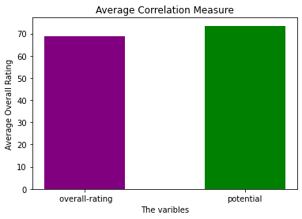

```python
# correlation visualization using bar chart
locations = [1, 2]
heights = df_pa[['overall_rating', 'potential']].mean() # the variable will have the mean value of the two variable
labels = [' overall-rating', 'potential']
plt.bar(locations, heights, tick_label=labels, color = ('purple', 'green'), width = 0.5)
plt.title('Average Correlation Measure')
plt.xlabel('The varibles')
plt.ylabel('Average Overall Rating');
plt.show()
```

### Report on Question #2

- To identify the independent variable with better correlation against the dependent variable, six independent variables has selected. The variables has been explored and visualized using scatter plot to find out the correlation against the dependent variable. Accordingly, as we can see from the figures, the variable **potential** has higher positive correlation with the dependent variable i.e. **overall_rating**. They have better relationship between them and we can say that as the potential increases the overall rating of the player would also go up. Next to that the variable **vision** has better correlation with the dependent variable out of the rest.
- It has been also visualized and explored using bar chart taking the mean value of the variables. The finding out of the later technique is also analogous to the former one.

### Research Question 3 : Which type of prefered foot (left or right) is associated with high player rating?

- To answer this quetion, groupby is introduced to group in terms of left and right preferred foot player. After that, an average value of overall rating for each group has to be computed. Based on that, visualzation would be conducted.

```python
# 1. let's define a function for handling repetative functionalities and for this question
def myPlot(df, grpVar, yVar, color = ('purple', 'blue')):
    # df: is the data frame pass from the callee
    # grpVar: is the variable that represent the graph on the x axis
    # yvar: the varible that shows its value on the y axis

    # 2. plot, using the groupby with the mean value, it plots on the x axis which is important feature of groupby
    df.groupby(grpVar)[yVar].mean().plot.bar(edgecolor ='black', figsize =[15,8], rot = 0, width = 0.8, color = color);
    grpVar = grpVar.replace("_", " ") # replacing the _ with space
    yVar = yVar.replace("_ ", " ")  # replacing the _ with space
    # 3. Add title and format
    plt.title(f'Average {yVar} by {grpVar}'.title(), fontsize = 14, weight = 'bold')
    # 4. Adding x lable
    plt.xlabel(grpVar.title(), fontsize = 10, weight = 'bold')
    # 5 Add y label
    plt.ylabel(f'Average {yVar}'.title(), fontsize = 10, weight = 'bold')
```

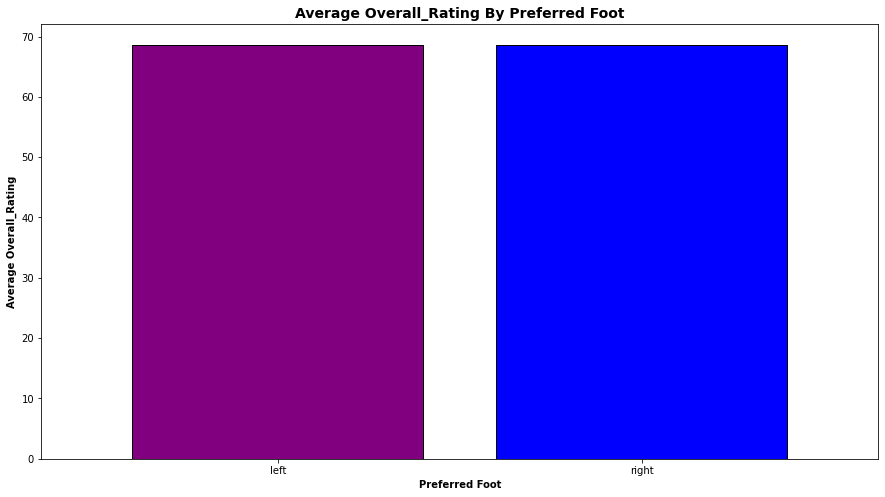

```python
# clling the plot function
myPlot(df_pa, 'preferred_foot', 'overall_rating')
```

### Report on Question #3:

As we can see from the figuer, players who are preferred with either left or right foot are rated close similarly with slight differences. All in all, we can say that, the left foot player has higher overall rating based on the above finding.

### Question 4: Do player with higher dribble skill receive better ratings?

- in this question, it is expected to identify the median of the variable dribbling and creating two sub dataframe. Next, the avearge of **overall_rating** of each class will be computed.

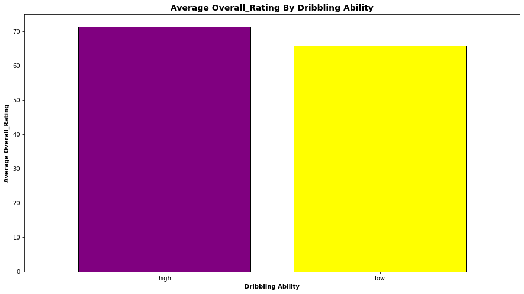

```python
# create dribbling ability variable
# 1 let the default is high
df_pa['dribbling ability'] = 'high'
# 2. change the rows below median to low
df_pa.loc[df_pa['dribbling'] < df_pa['dribbling'].median(), 'dribbling ability'] = 'low'
# call the plot fumction
myPlot(df_pa, 'dribbling ability', 'overall_rating', color = ('purple', 'yellow'))
```

### Report on Question #4:

- as we can see from the above visulization, players with high dribbiling skill has better overall rating. To do this the low dribbler and high dribbler player observation has been classified using the median. Then again these two class are computed towards the average value of the overall rating and generated the above figuer. Thus, players with high dribbling skill has better overall rating value.

### Question 5: What is the name of the player that has better rating?

- To answer this question, concept of querying and joining are more importantly need to be consisdered since the infrmation is obtained from two different datasets.

```python
# just checking the Player dataset
df_p.head(1)
```

|  | id | player_api_id | player_name | player_fifa_api_id | birthday | height | weight |
| --- | --- | --- | --- | --- | --- | --- | --- |
| 0 | 1 | 505942 | Aaron Appindangoye | 218353 | 1992-02-29 00:00:00 | 182.88 | 187 |

```python
# selecting datasets with maximum overall rate
df_pa_max_rate = df_pa['overall_rating'].max() # filtering with max overall rating
df_max_pa_rate = df_pa.query('overall_rating == {}'.format(df_pa_max_rate)) # querying using max value
df_max_pa_rate.head(1)
```

|  | id | player_fifa_api_id | player_api_id | date | overall_rating | potential | preferred_foot | attacking_work_rate | defensive_work_rate | crossing | ... | penalties | marking | standing_tackle | sliding_tackle | gk_diving | gk_handling | gk_kicking | gk_positioning | gk_reflexes | dribbling ability |
| --- | --- | --- | --- | --- | --- | --- | --- | --- | --- | --- | --- | --- | --- | --- | --- | --- | --- | --- | --- | --- | --- |
| 102482 | 102483 | 158023 | 30981 | 2015-12-17 00:00:00 | 94 | 94.0 | left | medium | low | 80.0 | ... | 74.0 | 13.0 | 23.0 | 21.0 | 6.0 | 11.0 | 15.0 | 14.0 | 8.0 | high |

1 rows × 43 columns

```python
# combining both dataframe with inner join using player_api_id [player and player attribute]
df_combined = df_p.merge(df_max_pa_rate, left_on='player_api_id', right_on='player_api_id', how='inner') # merging using inner join
df_combined.head(1)
```

|  | id_x | player_api_id | player_name | player_fifa_api_id_x | birthday | height | weight | id_y | player_fifa_api_id_y | date | ... | penalties | marking | standing_tackle | sliding_tackle | gk_diving | gk_handling | gk_kicking | gk_positioning | gk_reflexes | dribbling ability |
| --- | --- | --- | --- | --- | --- | --- | --- | --- | --- | --- | --- | --- | --- | --- | --- | --- | --- | --- | --- | --- | --- |
| 0 | 6176 | 30981 | Lionel Messi | 158023 | 1987-06-24 00:00:00 | 170.18 | 159 | 102483 | 158023 | 2015-12-17 00:00:00 | ... | 74.0 | 13.0 | 23.0 | 21.0 | 6.0 | 11.0 | 15.0 | 14.0 | 8.0 | high |

1 rows × 49 columns

```python
# rendering the name of the player highly rated
df_combined['player_name'].unique()
```

```
array(['Lionel Messi'], dtype=object)
```

### Report on question #5

- In this question, the player attribute data frame has been filtered using max() panadas built in function. Next to that new data frame is created using the merge, which combines the filtered **player attribute** and **player** data frames using inner join.
- Accordingly, the name of highly rated player is identified as **Lionel Messi**

### Question 6: Which players had the most penalties?

```python
# identifying the maximum penality value
df_max = df_pa['penalties'].max()
df_max
```

```
96.0
```

```python
# filtering using the maximum value
df_max_pa_filter = df_pa.query('penalties == {}'.format(df_max))
df_max_pa_filter
```

|  | id | player_fifa_api_id | player_api_id | date | overall_rating | potential | preferred_foot | attacking_work_rate | defensive_work_rate | crossing | ... | penalties | marking | standing_tackle | sliding_tackle | gk_diving | gk_handling | gk_kicking | gk_positioning | gk_reflexes | dribbling ability |
| --- | --- | --- | --- | --- | --- | --- | --- | --- | --- | --- | --- | --- | --- | --- | --- | --- | --- | --- | --- | --- | --- |
| 149591 | 149592 | 13879 | 39225 | 2016-03-10 00:00:00 | 75 | 75.0 | right | high | medium | 67.0 | ... | 96.0 | 30.0 | 26.0 | 19.0 | 13.0 | 15.0 | 7.0 | 16.0 | 11.0 | high |
| 149592 | 149593 | 13879 | 39225 | 2015-12-24 00:00:00 | 75 | 75.0 | right | high | medium | 67.0 | ... | 96.0 | 30.0 | 26.0 | 19.0 | 13.0 | 15.0 | 7.0 | 16.0 | 11.0 | high |
| 149593 | 149594 | 13879 | 39225 | 2015-10-23 00:00:00 | 75 | 75.0 | right | high | medium | 67.0 | ... | 96.0 | 30.0 | 26.0 | 19.0 | 13.0 | 15.0 | 7.0 | 16.0 | 11.0 | high |
| 149594 | 149595 | 13879 | 39225 | 2015-09-21 00:00:00 | 75 | 75.0 | right | high | medium | 67.0 | ... | 96.0 | 30.0 | 26.0 | 19.0 | 13.0 | 15.0 | 7.0 | 16.0 | 11.0 | high |

4 rows × 43 columns

```python
# mering two different datasets using inner join
df_combined1 = df_p.merge(df_max_pa_filter, left_on='player_api_id', right_on='player_api_id', how='inner')
df_combined1.head()
```

|  | id_x | player_api_id | player_name | player_fifa_api_id_x | birthday | height | weight | id_y | player_fifa_api_id_y | date | ... | penalties | marking | standing_tackle | sliding_tackle | gk_diving | gk_handling | gk_kicking | gk_positioning | gk_reflexes | dribbling ability |
| --- | --- | --- | --- | --- | --- | --- | --- | --- | --- | --- | --- | --- | --- | --- | --- | --- | --- | --- | --- | --- | --- |
| 0 | 8981 | 39225 | Rickie Lambert | 13879 | 1982-02-16 00:00:00 | 187.96 | 170 | 149592 | 13879 | 2016-03-10 00:00:00 | ... | 96.0 | 30.0 | 26.0 | 19.0 | 13.0 | 15.0 | 7.0 | 16.0 | 11.0 | high |
| 1 | 8981 | 39225 | Rickie Lambert | 13879 | 1982-02-16 00:00:00 | 187.96 | 170 | 149593 | 13879 | 2015-12-24 00:00:00 | ... | 96.0 | 30.0 | 26.0 | 19.0 | 13.0 | 15.0 | 7.0 | 16.0 | 11.0 | high |
| 2 | 8981 | 39225 | Rickie Lambert | 13879 | 1982-02-16 00:00:00 | 187.96 | 170 | 149594 | 13879 | 2015-10-23 00:00:00 | ... | 96.0 | 30.0 | 26.0 | 19.0 | 13.0 | 15.0 | 7.0 | 16.0 | 11.0 | high |
| 3 | 8981 | 39225 | Rickie Lambert | 13879 | 1982-02-16 00:00:00 | 187.96 | 170 | 149595 | 13879 | 2015-09-21 00:00:00 | ... | 96.0 | 30.0 | 26.0 | 19.0 | 13.0 | 15.0 | 7.0 | 16.0 | 11.0 | high |

4 rows × 49 columns

```python
df_combined1['player_name'].unique()
```

```
array(['Rickie Lambert'], dtype=object)
```

### Report on Question #6:

- in this question, filtering the player attribte using the max() built in function of **penalities** variable has been conducted. after that it has been merged with the player dataset using inner join. As we can see the player who taken most penality is **Rickie Lambert**.

## Conclusions

```python
from subprocess import call
call(['python', '-m', 'nbconvert', 'Investigate_a_Dataset.ipynb'])
```

```
1
```